### Kepler Objects of Interest: EDA and Modelling

# Introduction

Extrosolar planets may be discovered by detecting their host stars as the planets pass in front of them. Potential such host stars are referred to as “Kepler objects of interest”. The data given to us contains information on a set of 9177 Kepler objects of interest, with 18 predictor variables that measure aspects related to exoplanets, host stars, exoplanet orbits, and transit, and a response variable that states for each observation if we have identified a confirmed exoplanet (“CONFIRMED”), have not identified an exoplanet (“FALSE POSITIVE”), or are unsure of the nature of what we have found (“CANDIDATE”).

Our aim is to identify a model that may be trained in order to effectively differentiate between “CONFIRMED” and “FALSE POSITIVE” exoplanetary candidates.

```
## [1] "df"         "predictors" "response"
```

# Summary of given data

Firstly, looking at our dataset, it appears that koi_eccen has only zeroes in it, so we may remove this predictor as it will likely not contribute much to our analysis. Next, we must remove the rows which have a response of “CANDIDATE” from our dataset as we are only interested in predicting our responses as either “CONFIRMED” or “FALSE POSITIVE”. We will also split our data into test and training sets, keeping 80% of the data in our training set and the other portion in our test set.

```r
set.seed(101)
df$koi_eccen = NULL
predictors$koi_eccen = NULL
response = droplevels(response, "CANDIDATE")
indices.resp = which(response== "CONFIRMED" | response== "FALSE POSITIVE")
response = response[indices.resp]
rm.indices = which(df$y == "CANDIDATE")
df.candidate = df[rm.indices,]
pred.main = predictors
resp.main = response
df.main = df
df = df[-rm.indices,]
predictors = predictors[-rm.indices,]
indices = sample(c(1:nrow(predictors)),0.8*nrow(predictors))
pred.train = predictors[indices,]
resp.train = response[indices]
resp.test = response[-indices]
pred.test = predictors[-indices,]
```

Next, we will conduct a summary of our dataset.

```r
summary(df)
```

```
##    koi_period          koi_impact        koi_duration
##  Min.   :   0.2418   Min.   :  0.0000   Min.   :  0.1046
##  1st Qu.:   2.1132   1st Qu.:  0.2330   1st Qu.:  2.5379
##  Median :   7.4427   Median :  0.5920   Median :  3.9085
##  Mean   :  50.8026   Mean   :  0.7632   Mean   :  5.8514
##  3rd Qu.:  27.5014   3rd Qu.:  0.9220   3rd Qu.:  6.3490
##  Max.   :1071.2326   Max.   :100.8060   Max.   :138.5400
##    koi_depth            koi_ror            koi_srho
##  Min.   :      0.8   Min.   : 0.00129   Min.   :  0.0000
##  1st Qu.:    181.9   1st Qu.: 0.01320   1st Qu.:  0.1777
##  Median :    512.6   Median : 0.02453   Median :  0.7595
##  Mean   :  31492.3   Mean   : 0.30180   Mean   :  6.9371
##  3rd Qu.:   3031.6   3rd Qu.: 0.21976   3rd Qu.:  2.3885
##  Max.   :1541400.0   Max.   :99.87065   Max.   :980.8542
##     koi_prad            koi_sma          koi_incl        koi_teq
##  Min.   :     0.08   Min.   :0.0059   Min.   : 2.29   Min.   :   92.0
##  1st Qu.:     1.51   1st Qu.:0.0320   1st Qu.:81.37   1st Qu.:  583.5
##  Median :     2.71   Median :0.0741   Median :87.89   Median :  955.0
##  Mean   :   109.93   Mean   :0.1919   Mean   :80.81   Mean   : 1177.7
##  3rd Qu.:    26.82   3rd Qu.:0.1763   3rd Qu.:89.62   3rd Qu.: 1531.0
##  Max.   :200346.00   Max.   :2.1525   Max.   :90.00   Max.   :14667.0
##    koi_insol           koi_dor           koi_steff       koi_slogg
##  Min.   :       0   Min.   :   0.386   Min.   : 2661   Min.   :0.047
##  1st Qu.:      27   1st Qu.:   4.053   1st Qu.: 5325   1st Qu.:4.204
##  Median :     197   Median :  12.220   Median : 5780   Median :4.438
##  Mean   :    9897   Mean   :  55.334   Mean   : 5730   Mean   :4.304
##  3rd Qu.:    1298   3rd Qu.:  34.700   3rd Qu.: 6130   3rd Qu.:4.542
##  Max.   :10947555   Max.   :2421.700   Max.   :15896   Max.   :5.283
##     koi_smet          koi_srad         koi_smass                  y
##  Min.   :-2.5000   Min.   :  0.116   Min.   :0.094   CANDIDATE     :   0
##  1st Qu.:-0.2800   1st Qu.:  0.830   1st Qu.:0.844   CONFIRMED     :2296
##  Median :-0.1000   Median :  1.000   Median :0.974   FALSE POSITIVE:4563
##  Mean   :-0.1357   Mean   :  1.775   Mean   :1.029
##  3rd Qu.: 0.0600   3rd Qu.:  1.368   3rd Qu.:1.104
##  Max.   : 0.5600   Max.   :229.908   Max.   :3.686
```

Upon looking at the summary of the given data, we notice that there are significant differences between the mean and median values for the koi_period, koi_depth, koi_srho, koi_prad, koi_insol and koi_dor variables, indicating right skewness in the distribution for these variables. There also appear to be strong outliers for many of the variables (such as koi_period, koi_prad and koi_depth), indicated by the large differences between the maximum and third quartile values for these variables. The data for variables such as koi_smass, koi_steff and koi_slogg hints at symmetric distributions, shown by the closeness between their mean and median values.

# Distributions of variables

## Orbit-related variables

We may begin by creating diagrams to observe the distribution of our variables. To start with, we can create boxplots for all the orbit-related variables (all these variables seemed to have significant skew so we have chosen to plot all of them).

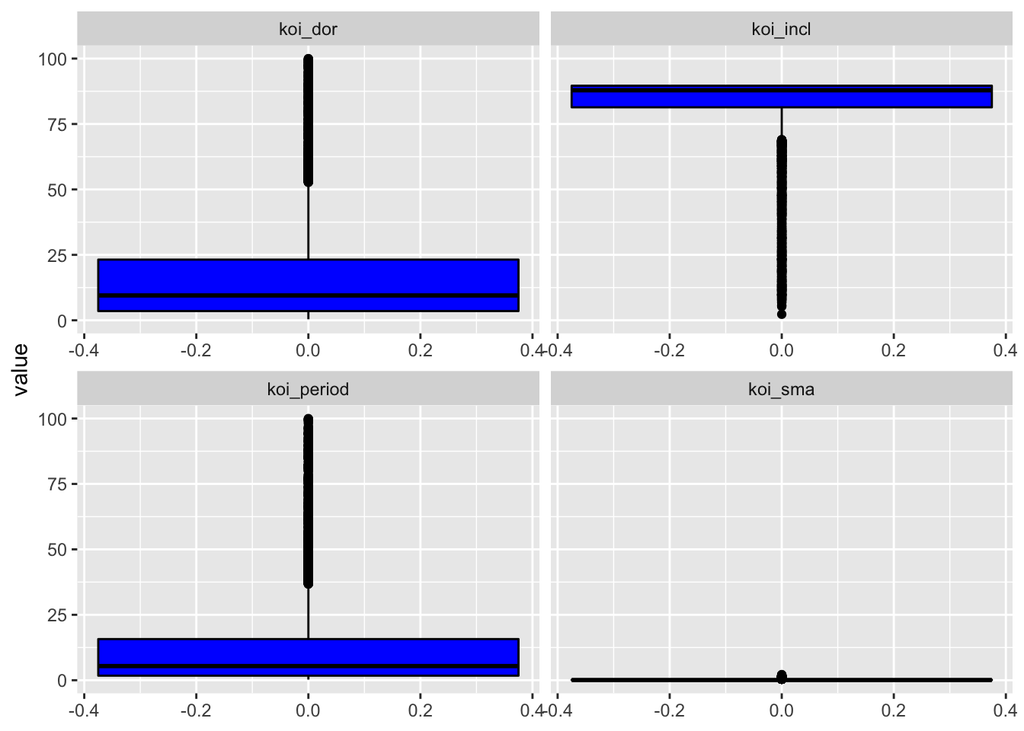

```r
pred.orbit = predictors[,c(1,8,9,12)]
pred.orbit = pred.orbit %>% gather(.)
ggplot(data = pred.orbit, mapping = aes(y=value))+ geom_boxplot(col="black",fill = "blue") + facet_wrap(~key,scales='free_x') + ylim(c(0,100))
```

Both koi_dor and koi_period appear to be quite right-skewed, with a considerable number of high outliers. In contrast, koi_incl appears to be rather left-skewed, with a considerable number of low outliers. We may create a separate boxplot for koi_sma as the current visualization makes it difficult to effectively analyze its distribution.

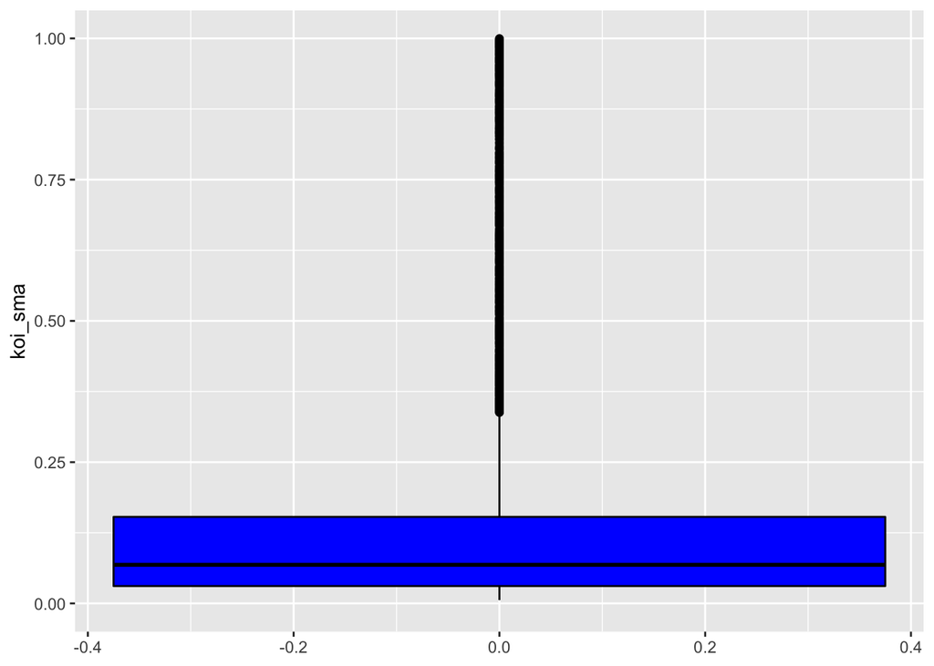

```r
ggplot(data = df, mapping = aes(y=koi_sma))+ geom_boxplot(col="black",fill = "blue") + ylim(c(0,1))
```

The distribution for koi_sma also appears to be rather right-skewed, with a considerable number of high outliers. The bulk of the values are contained between 0 and a little below 0.25.

## Transit/eclipse-related variables

Next, we may look at the distributions for the transit/eclipse-related variables, namely, koi_impact, koi_duration, and koi_depth. While the summaries of all three of these variables indicate high outliers and right skewness, the summary for koi_depth looks particularly interesting, as the mean value for this variable is considerably larger than the third quartile. To explore the skewness and distribution of koi_depth further, we may create a histogram (we can limit the range so as to exclude the high outliers):

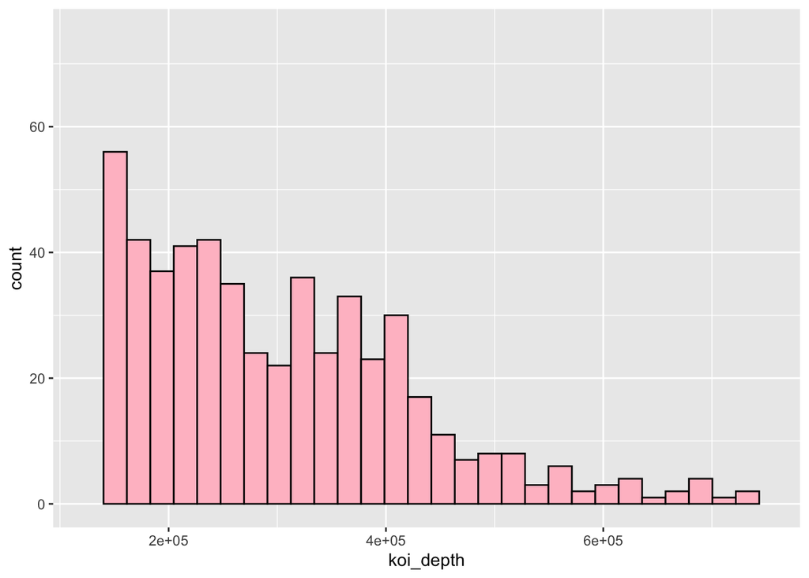

```r
ggplot(data = df, mapping = aes(x= koi_depth)) + geom_histogram(col = "black", fill="pink") + xlim(c(125000,750000)) + ylim(c(0,75))
```

The distribution is unimodal and fairly right-skewed, with some values exceeding 600000. The latter could be the reason for the large difference between the mean and third quartile, as well as the high outlier at around 1500000 (which has been excluded from the graph).

## Exoplanet property-related variables

Next, we may take a look at the exoplanet property-related variables, which are koi_ror, koi_prad, koi_teq and koi_insol. Again, there is evidence (from the summaries) to suggest that these variables have fairly right-skewed distributions. We may further explore the distributions for the koi_prad and koi_insol variables, which seem to have significantly high outliers and large differences between their mean and median values.

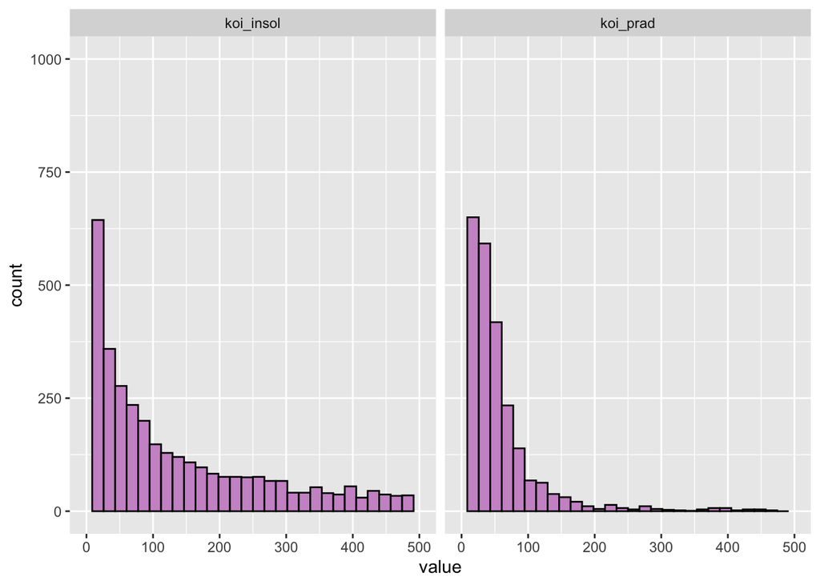

```r
pred.prop = predictors[,c(7,11)]
pred.prop = pred.prop %>% gather(.)
ggplot(data = pred.prop, mapping = aes(x=value))+ geom_histogram(col="black",fill = "plum3") + facet_wrap(~key,scales='free_x') + xlim(c(0,500)) +ylim(c(0,1000))
```

Upon creating histograms and limiting the ranges so that high outliers are excluded, we see that the distributions for these two variables are unimodal and rather right-skewed. Again, the larger mean values compared to the third quartile values may be explained by large outliers.

## Host star property-related variables

Finally, we may look at the distributions for the host star property-related variables (koi_srho, koi_steff, koi_slogg, koi_smet, koi_srad and koi_smass). Based on the summary we observed earlier, the variable that seems to have the most skewed distribution is koi_srho (due to the significant difference between its mean and median). Using a histogram to observe its distribution, we see the following:

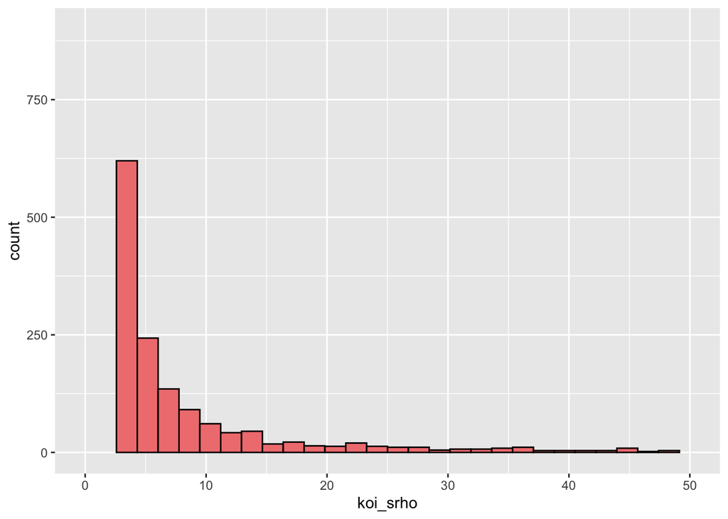

```r
ggplot(data = df, mapping = aes(x=koi_srho)) + geom_histogram(col = "black", fill = "lightcoral") + xlim(c(0,50)) + ylim(c(0,900))
```

Our histogram indicates that similar to some of the other variables we have observed, the distribution of koi_srho is unimodal and significantly right-skewed (and also has some high outliers which have been excluded).

# Examining relationships between variables

Before going on to conduct principal components analysis, it is useful to identify if any of the variables are strongly correlated with one another so as to reduce our number of predictors. We can examine this by constructing a correlation plot for our data as shown below.

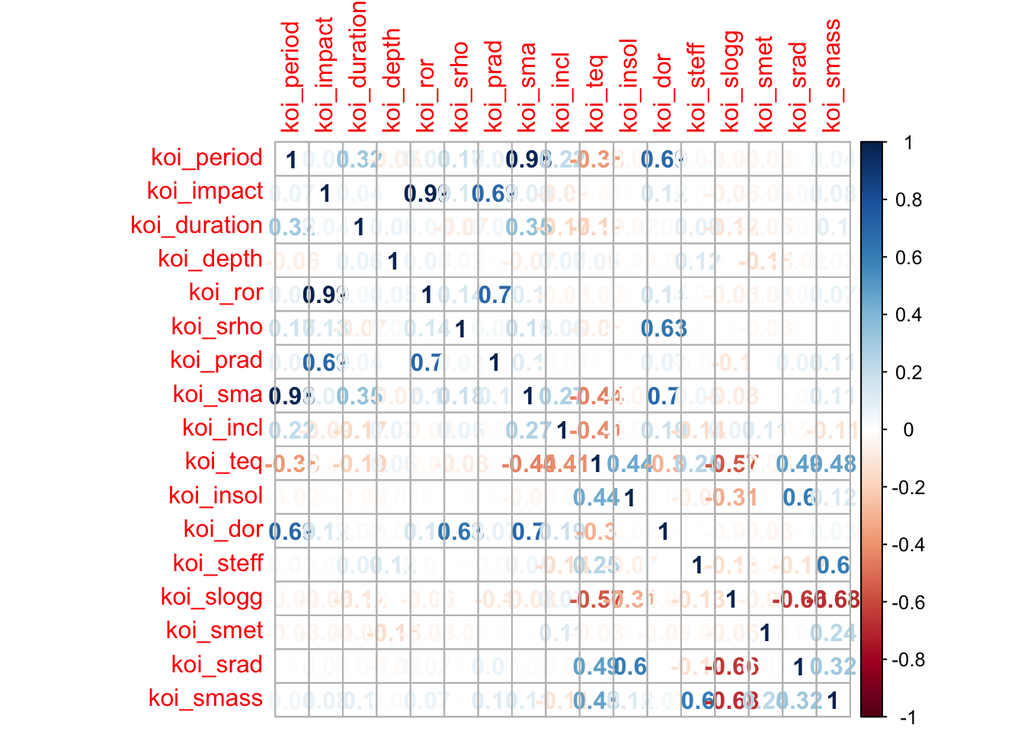

```r
library(corrplot)
corrplot(cor(predictors), method = "number")
```

As shown by the correlation plot above, there appear to be especially strong positive correlations between koi_impact and koi_ror, koi_sma and koi_period, and fairly strong positive correlations between koi_dor and koi_period, koi_sma and koi_dor, and koi_prad and koi_impact. There also appear to be fairly strong negative correlations between koi_srad and koi_slogg, as well as between koi_smass and koi_slogg.

We will observe the relationships between koi_impact and koi_ror, and between koi_sma and koi_period (as the positive correlation values between these variables were especially high), as well as the negative relationship between koi_slogg and koi_smass.

## Koi_impact vs. Koi_ror

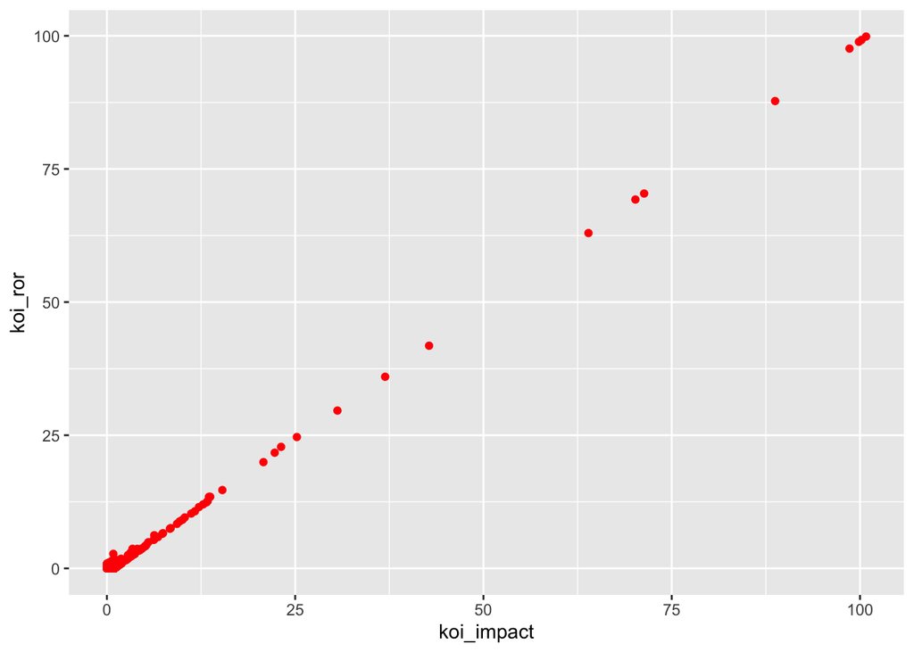

```r
ggplot(data = df, mapping = aes(x=koi_impact,y=koi_ror)) + geom_point(col="red")
```

As shown by the scatterplot above, there appears to be a very strong positive relationship between koi_impact and koi_ror, with most of the data points occuring between 0 and around 12 (on both the y and x-axes).

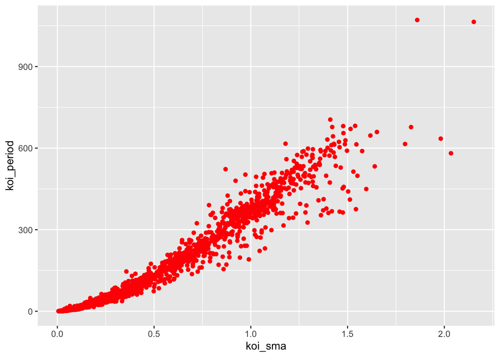

```r
ggplot(data = df, mapping = aes(x=koi_sma,y=koi_period)) + geom_point(col="red")
```

## Koi_slogg vs. Koi_smass

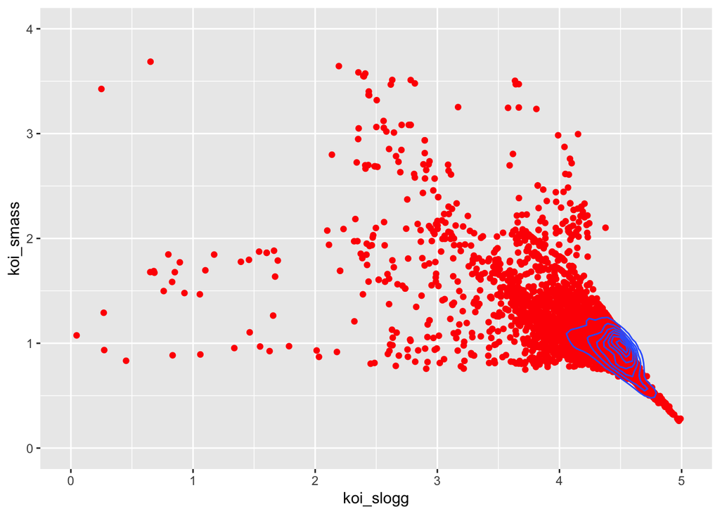

```r
ggplot(data = df, mapping = aes(x=koi_slogg,y=koi_smass)) + geom_point(col="red") + geom_density2d() + xlim(c(0,5)) + ylim(c(0,4))
```

There appears to be a somewhat negative relationship between koi_slogg and koi_smass, with values especially clustered in between 4 and 5 on the x-axis, and between 0.5 and around 1.25 on the y-axis (as shown by the density curve).

Because of the very high correlation values between koi_impact and koi_ror, as well as between koi_sma and koi_period, we can remove one variable each from these two pairs. From the first pair, we will remove koi_ror as we already have three other exoplanet property-related variables, and for the second pair, we will remove koi_sma.

```r
df = df[,-c(5,8)]
predictors = predictors[,-c(5,8)]
pred.train = pred.train[,-c(5,8)]
pred.test = pred.test[,-c(5,8)]
```

# PC Analysis

Given that we have a large number of variables in our dataset, conducting PCA would give us an idea of whether we could reduce the dimensionality of our predictor space.

```r
pr.out = prcomp(predictors, scale = TRUE)
pr.out
```

```
## Standard deviations (1, .., p=15):
##  [1] 1.7558594 1.5146772 1.2841763 1.2496420 1.1133023 1.1062887 1.0266126
##  [8] 0.8817759 0.8027052 0.7135257 0.5426840 0.5007857 0.4305466 0.3529665
## [15] 0.3294163
##
## Rotation (n x k) = (15 x 15):
##                        PC1          PC2          PC3         PC4
## koi_period    0.1470722636 -0.493800907  0.134154260 -0.15634916
## koi_impact   -0.0366796803 -0.277389113 -0.495167747  0.40661092
## koi_duration -0.0003562771 -0.166728373 -0.148956044 -0.21590436
## koi_depth    -0.0210874930  0.004836346 -0.097548478 -0.11645622
## koi_srho      0.0793578461 -0.376000821  0.128097461  0.00633866
## koi_prad     -0.0543384393 -0.258778971 -0.474972062  0.42266556
## koi_incl      0.1840742451 -0.142547228  0.297208675  0.04644831
## koi_teq      -0.4879141145  0.132941220 -0.005502955  0.03056192
## koi_insol    -0.3128013884 -0.051732149  0.326831527  0.27493378
## koi_dor       0.1454862189 -0.552745874  0.186160726 -0.07759558
## koi_steff    -0.1828438138 -0.077207812 -0.313899848 -0.53442451
## koi_slogg     0.4588378165  0.191651020 -0.098373706  0.03603747
## koi_smet     -0.0440705970 -0.010573692  0.069550316 -0.09118922
## koi_srad     -0.4049922125 -0.128502649  0.314182539  0.25293234
## koi_smass    -0.4079826420 -0.193746847 -0.146642938 -0.35701508
##                      PC5         PC6          PC7           PC8
## koi_period    0.13650667 -0.26996069  0.022727406 -0.1979952829
## koi_impact   -0.06820829  0.02289086 -0.023637226  0.0186891723
## koi_duration  0.43918623 -0.56150286  0.064456605  0.3370790282
## koi_depth     0.34078767  0.27457172 -0.708337080  0.4498746047
## koi_srho     -0.02807459  0.53349697  0.226927708  0.3426571427
## koi_prad     -0.11236840 -0.07808840 -0.130843507 -0.0667200074
## koi_incl     -0.30808126 -0.07352877 -0.613701248 -0.3028129130
## koi_teq       0.04356384  0.24582867  0.112720794 -0.0002084703
## koi_insol     0.15420304 -0.03036754 -0.030494524  0.0254988649
## koi_dor       0.01681674  0.21404202  0.131432819  0.0090189605
## koi_steff    -0.05631718  0.18188206 -0.058800946 -0.2766122673
## koi_slogg     0.01126633  0.12058846  0.066971824  0.0464481782
## koi_smet     -0.68009245 -0.26457185  0.009296379  0.5891789344
## koi_srad      0.09684989 -0.12001147 -0.062796937  0.0045652067
## koi_smass    -0.24124778 -0.02464256 -0.070000789 -0.0657419174
##                        PC9         PC10          PC11        PC12
## koi_period    0.1327474130 -0.450870402  0.0055923632  0.09467307
```

[output cut: 15 more lines]

```
## koi_period    0.30332086 -0.404141721 -0.27499481
## koi_impact    0.06681213 -0.002555168  0.03883272
## koi_duration  0.15897125  0.118615693  0.19872260
## koi_depth    -0.04401370 -0.033848934 -0.03709018
## koi_srho      0.11380948 -0.291519067 -0.23663079
## koi_prad     -0.01211374  0.029103246 -0.04888591
## koi_incl      0.25875414  0.050513009  0.14623659
## koi_teq       0.65801298  0.052423185  0.28284516
## koi_insol    -0.31457084 -0.007930197 -0.10308466
## koi_dor      -0.16439074  0.541748795  0.43415725
## koi_steff     0.13876796  0.269802703 -0.26859427
## koi_slogg     0.16831106 -0.333600100  0.50716278
## koi_smet      0.13159394  0.112495045 -0.09427657
## koi_srad      0.14472664 -0.068700885  0.10627339
## koi_smass    -0.38918164 -0.485082746  0.41662333
```

We may now construct a plot to observe the cumulative proportions of variance explained by our 15 principal components, so as to determine which ones we must retain:

[figure not shown]

```r
pve = 100*pr.out$sdev^2/sum(pr.out$sdev^2)
par(mfrow=c(1,2))
df.new = data.frame("x" = 1:15, "y" = cumsum(pve))
ggplot(data = df.new, mapping = aes(x,y)) + geom_point() + geom_line() + xlab("Cumulative PVE") + ylab("Principal Component")
```

As shown above, approximately 90% of the variance is explained by the first 9 principal components, so we do not have much need to retain the other 6. This is validated by our summary of pr.out, in which around 90.2% of variance is explained by the first 9 principle components as shown below.

```r
summary(pr.out)
```

```
## Importance of components:
##                           PC1    PC2    PC3    PC4     PC5     PC6     PC7
## Standard deviation     1.7559 1.5147 1.2842 1.2496 1.11330 1.10629 1.02661
## Proportion of Variance 0.2055 0.1530 0.1099 0.1041 0.08263 0.08159 0.07026
## Cumulative Proportion  0.2055 0.3585 0.4684 0.5725 0.65516 0.73675 0.80702
##                            PC8     PC9    PC10    PC11    PC12    PC13
## Standard deviation     0.88178 0.80271 0.71353 0.54268 0.50079 0.43055
## Proportion of Variance 0.05184 0.04296 0.03394 0.01963 0.01672 0.01236
## Cumulative Proportion  0.85885 0.90181 0.93575 0.95538 0.97210 0.98446
##                           PC14    PC15
## Standard deviation     0.35297 0.32942
## Proportion of Variance 0.00831 0.00723
## Cumulative Proportion  0.99277 1.00000
```

Now, we may create a new dataset with only our 9 retained principal components (which we will need when conducting logistic regression analysis).

```r
set.seed(101)
pca.pred.df = data.frame(predict(pr.out, predictors)[,1:9])
pca.pred.train = pca.pred.df[indices,]
pca.pred.test = pca.pred.df[-indices,]
pca.df = data.frame(pca.pred.df, response)
```

## Regression Analyses

We may now attempt to apply regression models to our data, and observe which ones provide us with the best fit (by identifying which ones yield the lowest misclassification rate).

We can start with a logistic regression model:

```r
set.seed(101)
#Using our main training and test data
glm.out = glm(resp.train~., data = pred.train, family = binomial)
summary(glm.out)
```

```
##
## Call:
## glm(formula = resp.train ~ ., family = binomial, data = pred.train)
##
## Deviance Residuals:
##     Min       1Q   Median       3Q      Max
## -4.4112  -0.4996   0.0098   0.3219   2.9298
##
## Coefficients:
##                Estimate Std. Error z value Pr(>|z|)
## (Intercept)  -2.455e+01  3.486e+00  -7.042 1.89e-12 ***
## koi_period   -6.590e-04  1.490e-03  -0.442 0.658232
## koi_impact    9.475e-01  1.912e-01   4.957 7.18e-07 ***
## koi_duration  2.682e-01  2.371e-02  11.312  < 2e-16 ***
## koi_depth     2.112e-05  8.342e-06   2.531 0.011363 *
## koi_srho      6.224e-02  1.096e-02   5.677 1.37e-08 ***
## koi_prad      9.560e-02  1.026e-02   9.314  < 2e-16 ***
## koi_incl     -3.614e-02  1.248e-02  -2.897 0.003772 **
## koi_teq       3.750e-03  1.930e-04  19.426  < 2e-16 ***
## koi_insol    -1.414e-05  3.795e-06  -3.726 0.000194 ***
## koi_dor       1.705e-02  2.269e-03   7.516 5.67e-14 ***
## koi_steff    -7.268e-05  2.070e-04  -0.351 0.725448
## koi_slogg     4.448e+00  5.729e-01   7.764 8.25e-15 ***
## koi_smet     -3.294e+00  2.865e-01 -11.498  < 2e-16 ***
## koi_srad      8.474e-01  3.051e-01   2.778 0.005475 **
## koi_smass     7.997e-01  8.270e-01   0.967 0.333539
## ---
## Signif. codes:  0 '***' 0.001 '**' 0.01 '*' 0.05 '.' 0.1 ' ' 1
##
## (Dispersion parameter for binomial family taken to be 1)
##
##     Null deviance: 7007.1  on 5486  degrees of freedom
## Residual deviance: 3229.8  on 5471  degrees of freedom
## AIC: 3261.8
##
## Number of Fisher Scoring iterations: 12
```

```r
resp.prob = predict(glm.out,newdata=pred.test,type="response")
resp.pred = rep(NA,length(resp.prob))
for ( ii in 1:length(resp.prob) ) {
  if (resp.prob[ii] < 0.5) {
    resp.pred[ii] = "CONFIRMED"
  } else {
    resp.pred[ii] = "FALSE POSITIVE"
  }
}
tb = table(resp.pred, resp.test)
tb
```

```
##                 resp.test
## resp.pred        CONFIRMED FALSE POSITIVE
##   CONFIRMED            397            113
##   FALSE POSITIVE        54            808
```

```r
mcr.glm = 1-sum(tb[1,1], tb[2,2])/sum(tb[1,1], tb[1,2], tb[2,1], tb[2,2])
mcr.glm
```

```
## [1] 0.1217201
```

```r
#Using our PCA training and test data
glm.out.pca = glm(resp.train~., data = pca.pred.train, family = binomial)
summary(glm.out.pca)
```

```
##
## Call:
## glm(formula = resp.train ~ ., family = binomial, data = pca.pred.train)
##
## Deviance Residuals:
##     Min       1Q   Median       3Q      Max
## -4.3611  -0.5346   0.0099   0.3833   2.9093
##
## Coefficients:
##             Estimate Std. Error z value Pr(>|z|)
## (Intercept)   5.6883     0.2865  19.855  < 2e-16 ***
## PC1          -5.1762     0.2928 -17.681  < 2e-16 ***
## PC2          -5.2394     0.3086 -16.978  < 2e-16 ***
## PC3          -0.9942     0.3532  -2.815  0.00488 **
## PC4           5.7235     0.4866  11.762  < 2e-16 ***
## PC5           5.3440     0.2790  19.155  < 2e-16 ***
## PC6           3.8293     0.3092  12.386  < 2e-16 ***
## PC7          -4.7573     0.5126  -9.280  < 2e-16 ***
## PC8           5.1630     0.3880  13.307  < 2e-16 ***
## PC9           6.4595     0.4367  14.792  < 2e-16 ***
## ---
## Signif. codes:  0 '***' 0.001 '**' 0.01 '*' 0.05 '.' 0.1 ' ' 1
##
## (Dispersion parameter for binomial family taken to be 1)
##
##     Null deviance: 7007.1  on 5486  degrees of freedom
## Residual deviance: 3450.3  on 5477  degrees of freedom
## AIC: 3470.3
##
## Number of Fisher Scoring iterations: 10
```

```r
resp.prob.pca = predict(glm.out.pca,newdata=pca.pred.test,type="response")
resp.pred.pca = rep(NA,length(resp.prob.pca))
for ( ii in 1:length(resp.prob.pca) ) {
  if (resp.prob.pca[ii] < 0.5) {
    resp.pred.pca[ii] = "CONFIRMED"
  } else {
    resp.pred.pca[ii] = "FALSE POSITIVE"
  }
}
tb.pca = table(resp.pred.pca, resp.test)
tb.pca
```

```
##                 resp.test
## resp.pred.pca    CONFIRMED FALSE POSITIVE
##   CONFIRMED            388            114
##   FALSE POSITIVE        63            807
```

```r
mcr.glm.pca = 1-sum(tb.pca[1,1], tb.pca[2,2])/sum(tb.pca[1,1], tb.pca[1,2], tb.pca[2,1], tb.pca[2,2])
mcr.glm.pca
```

```
## [1] 0.1290087
```

Since our MCR for logistic regression conducted on our regular training and test data (12.2%) is approximately the same as the MCR we receive when we conduct logistic regression on the training and test data we obtained through PCA (12.9%), we can continue to use our regular data when trying out potential models.

Next, we can attempt to conduct a linear discriminant analysis:

```
## Call:
## lda(resp.train ~ ., data = pred.train)
##
## Prior probabilities of groups:
##      CONFIRMED FALSE POSITIVE
##      0.3362493      0.6637507
##
## Group means:
##                koi_period koi_impact koi_duration koi_depth koi_srho
## CONFIRMED        28.13823  0.4319507     4.341695  1144.187 2.402261
## FALSE POSITIVE   62.02687  0.8796037     6.605715 47382.016 8.886724
##                  koi_prad koi_incl   koi_teq  koi_insol  koi_dor koi_steff
## CONFIRMED        2.902325 87.88878  835.4341   339.4996 31.70831  5475.168
## FALSE POSITIVE 122.077499 77.26126 1352.6936 13105.8473 67.04712  5867.166
##                koi_slogg    koi_smet koi_srad koi_smass
## CONFIRMED       4.410564 -0.01004878 1.063572 0.9348542
## FALSE POSITIVE  4.246454 -0.20446183 2.070767 1.0778344
##
## Coefficients of linear discriminants:
##                        LD1
## koi_period    4.381096e-03
## koi_impact    4.077609e-02
## koi_duration  2.372706e-02
## koi_depth     4.254164e-06
## koi_srho      3.190399e-04
## koi_prad     -3.305008e-05
## koi_incl     -2.444873e-02
## koi_teq       7.296092e-04
## koi_insol    -1.043824e-06
## koi_dor       9.947682e-04
## koi_steff     3.808880e-05
## koi_slogg     4.110138e-01
## koi_smet     -1.937382e+00
## koi_srad      1.136930e-02
## koi_smass     6.328156e-01
```

```
##                 resp.test
## lda.class        CONFIRMED FALSE POSITIVE
##   CONFIRMED            357            142
##   FALSE POSITIVE        94            779
```

```
## [1] 0.1720117
```

Next, we may attempt to generate a classification tree.

```r
library(rpart)
set.seed(101)
tree.pred=rpart(resp.train~., data = pred.train)

resp.prob.tree = predict(tree.pred, newdata = pred.test)
resp.pred.tree = rep(NA,length(resp.test))
for ( ii in 1:nrow(resp.prob.tree) ) {
  if (names(which.max(resp.prob.tree[ii,]))=="FALSE POSITIVE") {
    resp.pred.tree[ii] = "FALSE POSITIVE"
  } else if (names(which.max(resp.prob.tree[ii,]))=="CONFIRMED") {
    resp.pred.tree[ii] = "CONFIRMED"
  } else {
    resp.pred.tree[ii] = "CANDIDATE"
  }
}

tb3 = table(resp.pred.tree, resp.test)
tb3
```

```
##                 resp.test
## resp.pred.tree   CONFIRMED FALSE POSITIVE
##   CONFIRMED            413            124
##   FALSE POSITIVE        38            797
```

```r
mcr.class = 1-sum(tb3[1,1], tb3[2,2])/sum(tb3[1,1], tb3[1,2], tb3[2,1], tb3[2,2])
mcr.class
```

```
## [1] 0.1180758
```

Our misclassification rate is approximately 11.8%, which is lower than for our other models, so we would want to consider this model as the best option for our data if subsequent models do not yield a lower misclassification rate.

Next, we may try implementing a ridge regression model.

```
##                 resp.test
## resp.pred.ridge  CONFIRMED FALSE POSITIVE
##   CONFIRMED            360            117
##   FALSE POSITIVE        91            804
```

```
## [1] 0.1516035
```

We receive an MCR of 15% which is higher than for some of the models we have seen, so we will not use this model.

```
##                   resp.test
## resp.lasso.predict CONFIRMED FALSE POSITIVE
##     CONFIRMED            397            107
##     FALSE POSITIVE        54            814
```

```
## [1] 0.1173469
```

Lastly, we will use a random forest model.

```r
set.seed(101)
library(randomForest)
rf.out = randomForest(resp.train~.,pred.train, importance = TRUE)
resp.prob.rf = predict(rf.out, pred.test)
resp.pred.rf = rep(NA,length(resp.test))
for ( ii in 1:length(resp.pred.rf) ) {
  if (resp.prob.rf[ii] == "FALSE POSITIVE") {
    resp.pred.rf[ii] = "FALSE POSITIVE"
  } else {
    resp.pred.rf[ii] = "CONFIRMED"
  }
}
tb.rf = table(resp.pred.rf, resp.test)
tb.rf
```

```
##                 resp.test
## resp.pred.rf     CONFIRMED FALSE POSITIVE
##   CONFIRMED            414             60
##   FALSE POSITIVE        37            861
```

```r
mcr.rf = 1-sum(diag(tb.rf))/sum(tb.rf)
mcr.rf
```

```
## [1] 0.07069971
```

We find that our misclassification rate is significantly lower than for all the other models, at 7.1%. So a random forest model is the best option for appropriately predicting responses.

## Conclusion

After attempting to fit six potential models to our data, namely logistic regression, a classification tree, linear discriminant analysis, ridge regression, lasso regression, and random forest analysis, we found that conducting a random forest analysis on our data yielded the lowest misclassification rate (as shown below). This suggests to us that a random forest model is likely the best possible option that would allow us to effectively categorize our exoplanetary candidates as either “CONFIRMED” or “FALSE POSITIVE”.

```
##      Name of Model                       Misclassification Rate (in %)
## [1,] "Logistic Regression"               "12.2"
## [2,] "Logistic Regression with PCA Data" "12.9"
## [3,] "Classification Tree"               "11.8"
## [4,] "LDA Analysis"                      "17.2"
## [5,] "Ridge Regression"                  "15.2"
## [6,] "Lasso Regression"                  "11.7"
## [7,] "Random Forest Analysis"            "7.1"
```